# Regression analysis and diagnostics for Albuquerque housing prices

This program reads data on housing prices in Albuquerque, New Mexico in 1993. Find more information in the [data dictionary](https://github.com/pmean/datasets/blob/master/albuquerque-housing.yaml).

This program was written by Steve Simon on 2024-08-18 and the code is placed in the public domain.

## Load the tidyverse library

For most of your programs, you should load the tidyverse library. The broom package provides a nice way to compute residuals and predicted values. The messages and warnings are suppressed.

```r
library(broom)
library(tidyverse)
```

# — Part 1: Diagnostic plots

## Read the data and view a brief summary

```r
alb <- read_csv(
  file="../data/albuquerque-housing.csv",
  col_names=TRUE,
  col_types="nnnnccc",
  na=".")
glimpse(alb)
```

```
Rows: 117
Columns: 7
$ price        <dbl> 205000, 208000, 215000, 215000, 199900, 190000, 180000, 1…
$ sqft         <dbl> 2650, 2600, 2664, 2921, 2580, 2580, 2774, 1920, 2150, 171…
$ age          <dbl> 13, NA, 6, 3, 4, 4, 2, 1, NA, 1, 4, 8, 15, 14, 18, NA, 16…
$ features     <dbl> 7, 4, 5, 6, 4, 4, 4, 5, 4, 3, 5, 6, 3, 5, 8, 3, 4, 3, 4, …
$ northeast    <chr> "yes", "yes", "yes", "yes", "yes", "yes", "yes", "yes", "…
$ custom_build <chr> "yes", "yes", "yes", "yes", "yes", "no", "no", "yes", "no…
$ corner_lot   <chr> "no", "no", "no", "no", "no", "no", "no", "no", "no", "no…
```

### Interpretation of the output

You might expect that a house with more features would have a higher sales price. Your first steps are to compute simple descriptive statistics for both the independent variable (features) and the dependent variable (price). Then you should plot the data.

## m1: Calculate descriptive statistics for number of features

```r
alb |>
  summarise(
    features_mn=mean(features, na.rm=TRUE),
    features_sd=sd(features, na.rm=TRUE),
    features_min=min(features, na.rm=TRUE),
    features_max=max(features, na.rm=TRUE),
    n_missing=sum(is.na(features)))
```

```
# A tibble: 1 × 5
  features_mn features_sd features_min features_max n_missing
        <dbl>       <dbl>        <dbl>        <dbl>     <int>
1        3.53        1.41            0            8         0
```

#### Interpretation of the output

The average number of features is small (3.5) and the standard deviation (1.4) indicates very little variation. At least one house has zero features and no house has all 13 features.

## m1: Calculate descriptive statistics for price

```r
alb |>
  summarize(
    price_mn=mean(price, na.rm=TRUE),
    price_sd=sd(price, na.rm=TRUE),
    price_min=min(price, na.rm=TRUE),
    price_max=max(price, na.rm=TRUE),
    n_missing=sum(is.na(price)))
```

```
# A tibble: 1 × 5
  price_mn price_sd price_min price_max n_missing
     <dbl>    <dbl>     <dbl>     <dbl>     <int>
1  106274.   38044.     54000    215000         0
```

#### Interpretation of the output

The average price is low ($106,000), but the standard deviation ($38,000) shows a fair amount of variation. Note that a dollar sign in R has special meaning. To get it to print normally, you have to put a backslash in front of it.

## m1: Plot features versus price

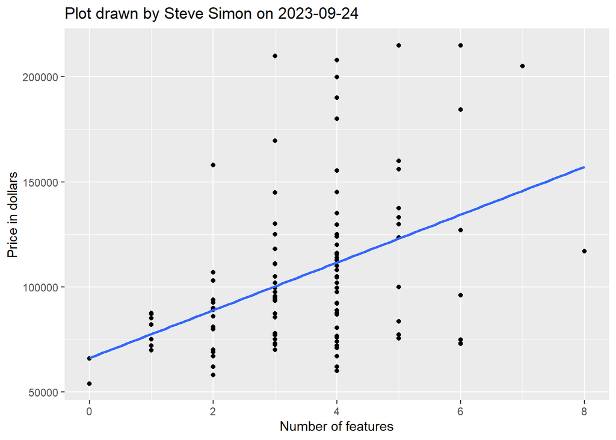

```r
alb |>
  ggplot(aes(features, price)) +
    geom_point() +
    geom_smooth(method="lm", se=FALSE) +
      ggtitle("Plot drawn by Steve Simon on 2023-09-24") +
      xlab("Number of features") +
      ylab("Price in dollars")
```

#### Interpretation of the output

There is a weak positive relationship between the number of features and the price of a house.

## m1: Use features to predict price

```r
m1 <- lm(price~features, data=alb)
m1
```

```
Call:
lm(formula = price ~ features, data = alb)

Coefficients:
(Intercept)     features
      66117        11376
```

#### Interpretation of the output

The estimated average sales price for a house with no features is $66,000. This is NOT an extrapolation beyond the range of the data. The estimated average sales price increases by $11,000 for each additional feature. This is surprisingly large when you look at what the features are. Perhaps houses with more features are bigger and newer.

## m1: Calculate residuals and predicted values

```r
r1 <- augment(m1)
glimpse(r1)
```

```
Rows: 117
Columns: 8
$ price      <dbl> 205000, 208000, 215000, 215000, 199900, 190000, 180000, 156…
$ features   <dbl> 7, 4, 5, 6, 4, 4, 4, 5, 4, 3, 5, 6, 3, 5, 8, 3, 4, 3, 4, 3,…
$ .fitted    <dbl> 145748.98, 111621.17, 122997.11, 134373.04, 111621.17, 1116…
$ .resid     <dbl> 59251.0183, 96378.8325, 92002.8944, 80626.9564, 88278.8325,…
$ .hat       <dbl> 0.061096606, 0.009511376, 0.017978366, 0.035173443, 0.00951…
$ .sigma     <dbl> 34348.09, 33620.33, 33719.15, 33963.04, 33816.76, 34032.12,…
$ .cooksd    <dbl> 1.012082e-01, 3.745903e-02, 6.563869e-02, 1.021705e-01, 3.1…
$ .std.resid <dbl> 1.76370021, 2.79316324, 2.67781374, 2.36752756, 2.55841645,…
```

### Comments on the code

Normally, you would follow this up with various functions like anova(), confint(), or tidy(). This program skips those steps to focus on the diagnostic plots of the residuals.

The [augment function](https://broom.tidymodels.org/reference/augment.lm.html), part of the broom library, calculates predicted values, residuals, and measures of influence.

You could have also used the [resid() function](https://broom.tidymodels.org/reference/augment.lm.html) and [predict() function](https://stat.ethz.ch/R-manual/R-devel/library/stats/html/predict.lm.html), both part of base R.

#### Interpretation of the output

No interpretation is needed here, as these numbers are better reviewed using various graphical displays.

## m1: Normal probability plot for residuals

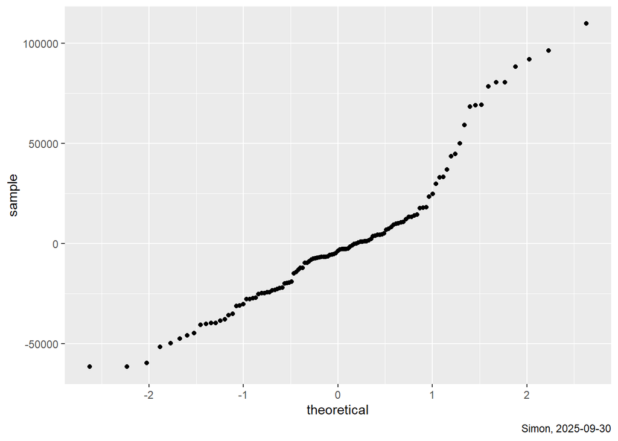

```r
r1 |>
  ggplot() +
  aes(sample=.resid) +
  stat_qq() +
  labs(
    caption="Simon, 2025-09-30")
```

#### Interpretation of the output

The normal probability plot deviates markedly from a straight line, indicating some possible issues with the normality assumption.

## m1: Histogram for residuals

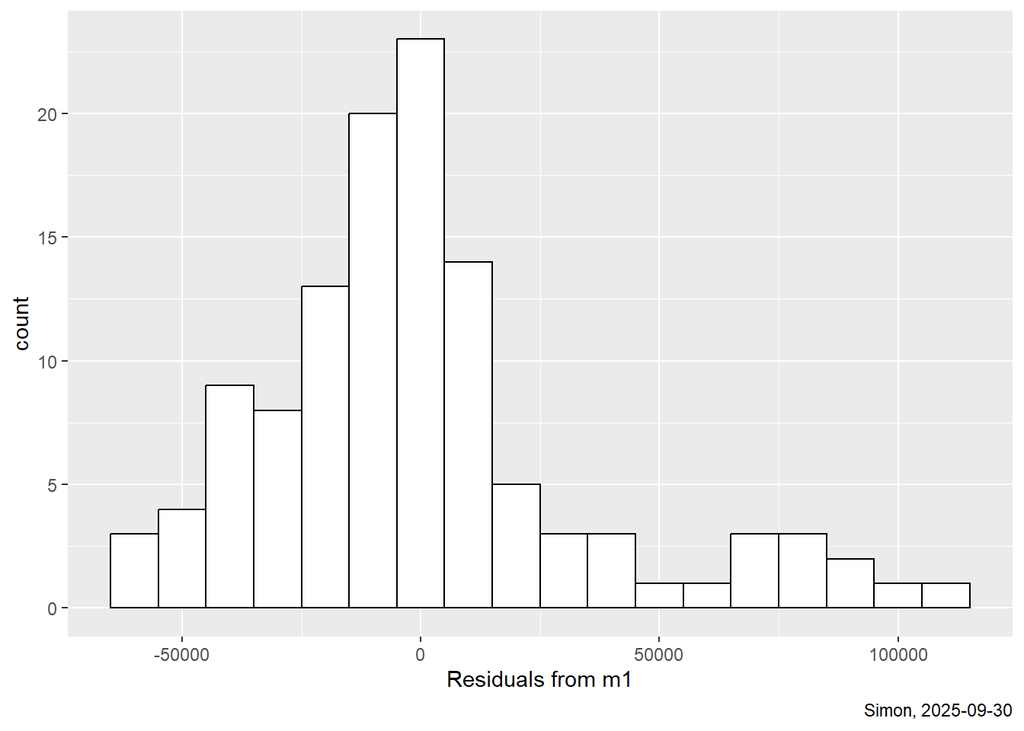

```r
r1 |>
  ggplot() +
  aes(.resid) +
  geom_histogram(
    binwidth=10000,
    color="black",
    fill="white") +
  labs(
    x="Residuals from m1",
    caption="Simon, 2025-09-30")
```

#### Interpretation of the output

The histogram reinforces these concerns. It looks like the data is skewed to the right.

## m1: Plot residuals versus features

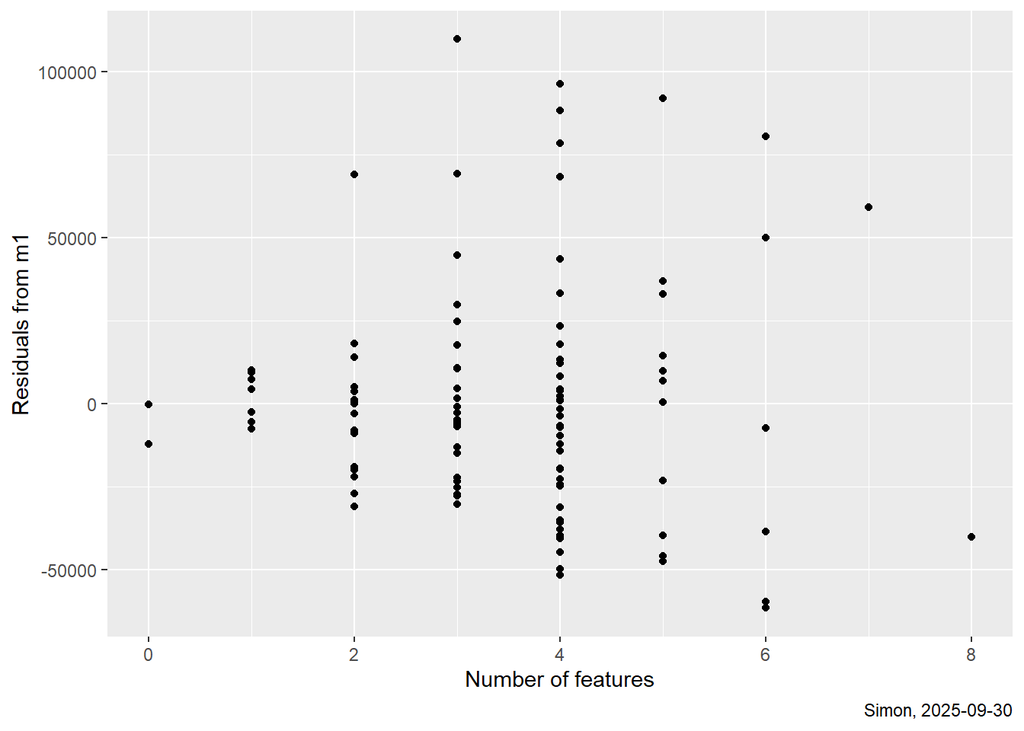

```r
r1 |>
  ggplot(aes(features, .resid)) +
  aes(features, .resid) +
  geom_point() +
  labs(
    x="Number of features",
    y="Residuals from m1",
    caption="Simon, 2025-09-30")
```

#### Interpretation of the output

This plot is difficult to interpret. There is some evidence of heterogeneity. It looks, perhaps, like houses with more features also tend to exhibit more variation. There is no evidence of non-linearity.

# — Part 2: Influence measures

## m1: Leverage values

```r
n <- nrow(r1)
r1 |> filter(.hat > 3*2/n)
```

```
# A tibble: 4 × 8
   price features .fitted  .resid   .hat .sigma     .cooksd .std.resid
   <dbl>    <dbl>   <dbl>   <dbl>  <dbl>  <dbl>       <dbl>      <dbl>
1 205000        7 145749.  59251. 0.0611 34348. 0.101          1.76
2 117000        8 157125. -40125. 0.0957 34597. 0.0784        -1.22
3  54000        0  66117. -12117. 0.0629 34803. 0.00438       -0.361
4  66000        0  66117.   -117. 0.0629 34822. 0.000000411   -0.00350
```

#### Interpretation of the output

There are four data points with high leverage. These correspond to the houses with the most and the fewest features.

## m1: Studentized deleted residual

```r
r1 |>
  filter(abs(.std.resid) > 3)
```

```
# A tibble: 1 × 8
   price features .fitted  .resid    .hat .sigma .cooksd .std.resid
   <dbl>    <dbl>   <dbl>   <dbl>   <dbl>  <dbl>   <dbl>      <dbl>
1 210000        3 100245. 109755. 0.00977 33255.  0.0499       3.18
```

## m1: Cook’s distance

```r
r1 |>
  filter(.cooksd > 1)
```

```
# A tibble: 0 × 8
# ℹ 8 variables: price <dbl>, features <dbl>, .fitted <dbl>, .resid <dbl>,
#   .hat <dbl>, .sigma <dbl>, .cooksd <dbl>, .std.resid <dbl>
```

#### Interpretation of the output

No houses had a large value for Cook’s distance. Even though there are a few high leverage points and one outlier, no single data point has unusually high influence on the predicted values.

# — Part 3: Log transformation

## m2: Using features to predict log(price)

Because there are some concerns about non-normality and heterogeneity, you might consider using a log transformation for price. In this example, a base 10 logarithm is a reasonable choice.

## m2: scatterplot

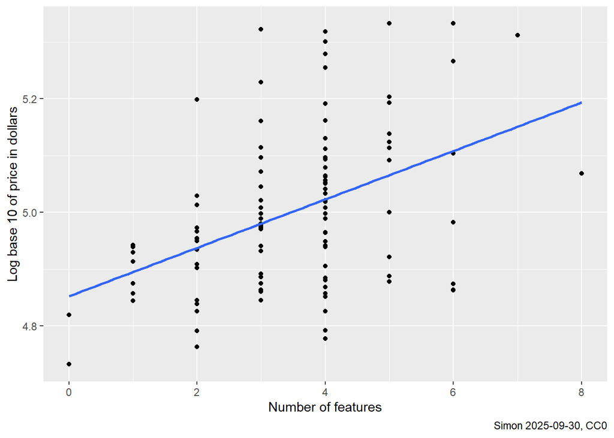

```r
alb |>
  mutate(log_price = log10(price)) -> alb1

alb1 |>
  ggplot(aes(features, log_price)) +
    geom_point() +
    geom_smooth(method="lm", se=FALSE) +
      labs(
        x="Number of features",
        y="Log base 10 of price in dollars",
        caption="Simon 2025-09-30, CC0")
```

#### Interpretation of the output

There is a weak positive linear relationship between log price and features.

## m2: linear regression on log transformed price

```r
m2 <- lm(log_price~features, data=alb1)
m2
```

```
Call:
lm(formula = log_price ~ features, data = alb1)

Coefficients:
(Intercept)     features
    4.85245      0.04263
```

#### Interpretation of the output

The estimated average log price is 4.8 for a house with no features. The estimated average log price increases by 0.043 for each additional feature. These numbers are easier to interpret when transformed back to the original scale.

## m2: Coefficients back transformed to original scale

```r
10^(coef(m2))
```

```
 (Intercept)     features
71195.269779     1.103135
```

#### Interpretation of the output

The estimated average price is $71,000 for a house with no features. The estimated average price increases by 1.10 (10%) for each additional feature.

## m2: Normal probability plot

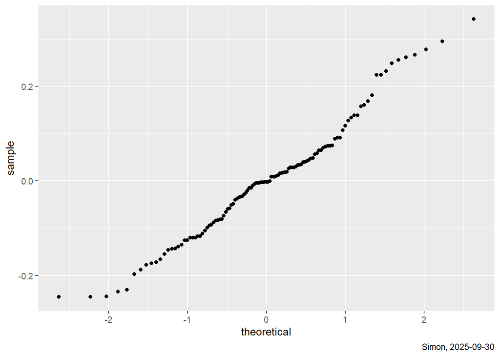

```r
r2 <- augment(m2)
r2 |>
  ggplot() +
  aes(sample=.resid) +
  stat_qq() +
  labs(
    caption="Simon, 2025-09-30")
```

#### Interpretation of the output

The normal probability plot is close to a straight line, indicating a reasonably close fit to a normal distribution.

## m2: Histogram of residuals

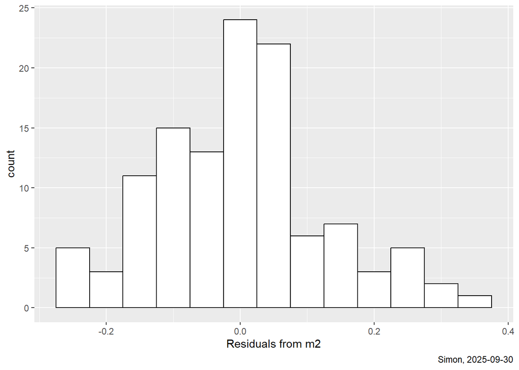

```r
r2 |>
  ggplot() +
  aes(.resid) +
  geom_histogram(
    binwidth=0.05,
    color="black",
    fill="white") +
     labs(
       x="Residuals from m2",
    caption="Simon, 2025-09-30")
```

#### Interpretation of the output

The histogram of residuals also indicates a close fit to a normal distribution. The regression model using log price does a better job meeting the normality assumption.

## m2: Plot residuals versus features

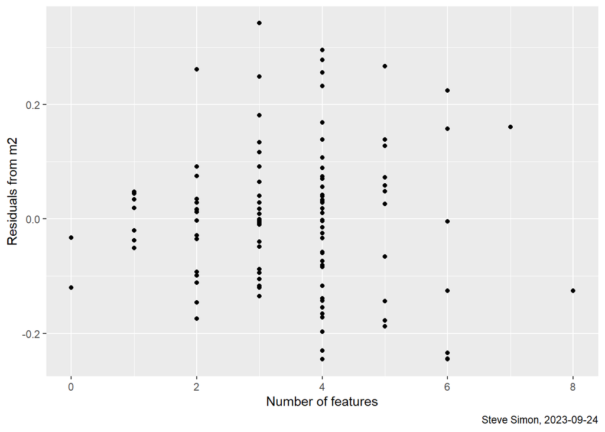

```r
r2 |>
  ggplot() +
  aes(features, .resid) +
  geom_point() +
  labs(
    caption="Steve Simon, 2023-09-24",
      x="Number of features",
      y="Residuals from m2")
```

#### Interpretation of the output

This plot is difficult to interpret. There is certainly no evidence of non-linearity, but perhaps the problems with heterogenity persist even after the log transformation. Houses with zero or one features seem to have less variation than the rest of the data.

## Additional analyses not done

As with the previous regression model, you may wish to do some inferential statistics with functions like anova(), confint(), or tidy(). You may also want to look at leverage, studentized deleted residuals, and Cook’s distance.